# Cok Degiskenli Istatistiksel Yontemler

## 8.2. $R^2$ Değerleri

```r
library("DescTools")
library(nnet)
multi_mo <- multinom(Ethnicity ~ Income+Limit+Rating+Cards+Age+Balance+Gender +Student + Married, data = kredi)
PseudoR2(multi_mo, which = c("CoxSnell","Nagelkerke","McFadden"))
```

```
##   CoxSnell Nagelkerke   McFadden
## 0.03371208 0.03850981 0.01646530
```

Test edilen diğer modeller arasında en yüksek R2 değeri olduğu için kullanılmıştır.

## 8.3. Sınıflandırma Tablosu

```r
tahminkat<-colnames(loj_kredi$probabilities)[max.col(loj_kredi$probabilities)]
tahminkat<-as.factor(tahminkat)
```

```r
kredi_table<- table(kredi$Ethnicity, tahminkat)
kredi_table
```

```
##                   tahminkat
##                    Asian Caucasian
##   Asian                0       102
##   Caucasian            3       196
##   African American     2        97
```

Asya kökenlilerin hiçbirini doğru atamamıştır.

Kafkasya kökenlilerin %98,5’ini doğru atamıştır.

Afrika ve Amerika kökenlilerin hiçbirini doğru atamamıştır.

```r
sum(diag(kredi_table)) / sum(kredi_table)
```

```
## [1] 0.49
```

Toplam atamanın %49,0’unu doğru atanmıştır.

# 9. Kümeleme Analizi

```r
kredi <- na.omit(kredi) # eksik gözlemlerin çikarilmasi
kredi_surekli = kredi[,c(1:5,11)]
str(kredi_surekli)
```

```
## 'data.frame':    400 obs. of  6 variables:
##  $ Income : num  14.9 106 104.6 148.9 55.9 ...
##  $ Limit  : num  3606 6645 7075 9504 4897 ...
##  $ Rating : num  283 483 514 681 357 569 259 512 266 491 ...
##  $ Cards  : num  2 3 4 3 2 4 2 2 5 3 ...
##  $ Age    : num  34 82 71 36 68 77 37 87 66 41 ...
##  $ Balance: num  333 903 580 964 331 ...
```

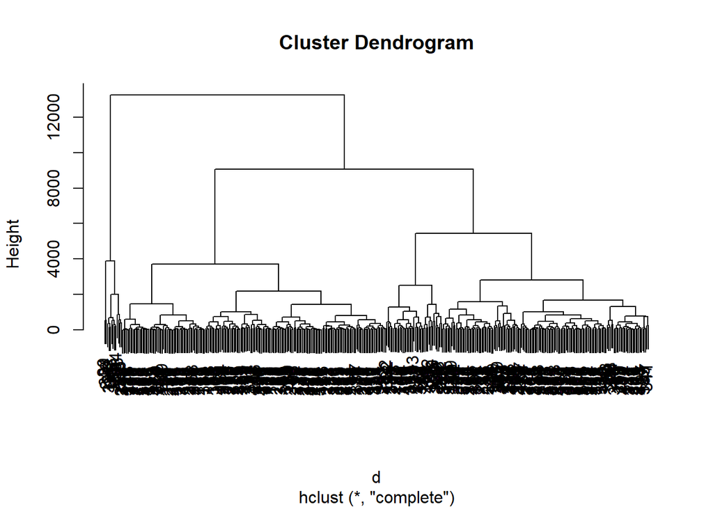

```r
d <- dist(kredi_surekli, method = "euclidean") # uzaklik matrisi
fit <- hclust(d, method="complete") # method="average" , "ward.D2", "single", "centroid"
plot(fit) # Dendogram çizimi
```

```r
d2 <- dist(kredi_surekli, method = "euclidean") # uzaklik matrisi
fit2 <- hclust(d2, method="complete")
```

# 10. Hiyerarşik Kümeleme Analizi

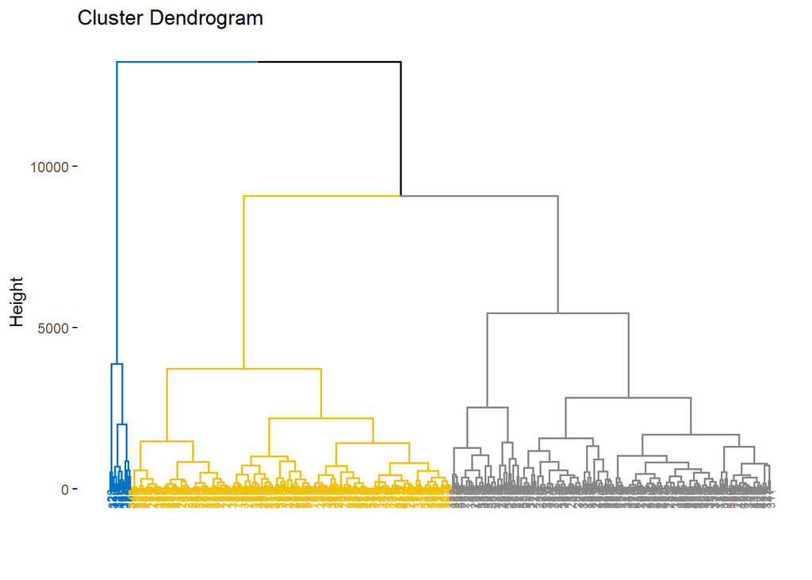

```r
library(factoextra)
res.hc <- hclust(d2,  method = "complete")
fviz_dend(res.hc, cex = 0.5, k = 3, palette = "jco")
```

# 11. K- Means Kümeleme Analizi

## 11.1. Küme Sayısının Belirlenmesi

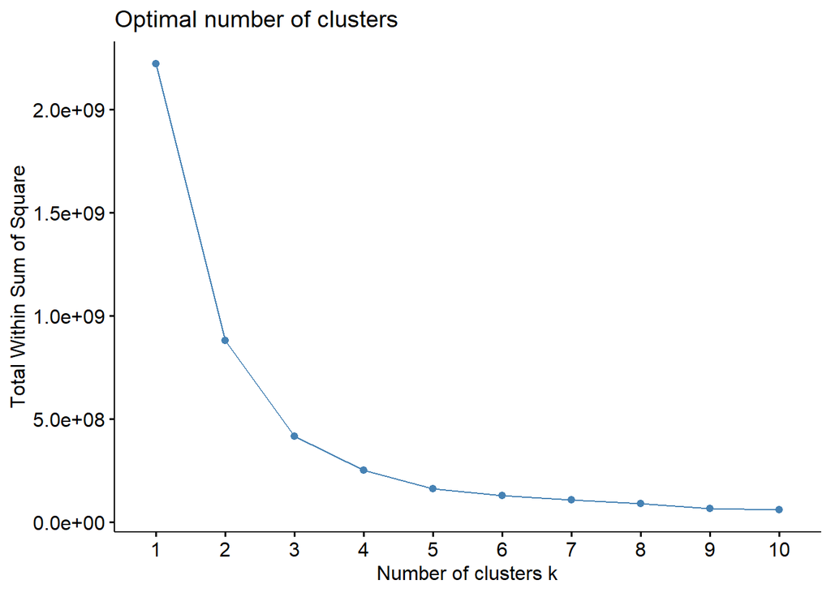

```r
fviz_nbclust(kredi_surekli, kmeans, method = "wss")
```

İterasyon 3 kümede tanımlanmıştır. Stabil olmuştur.

```r
set.seed(95739487) # for reproducibility
km.res <- kmeans(kredi_surekli,3, iter.max=10, algorithm="Lloyd")### initial[,-1] başlangıç kümelerini seçmek isterseniz
t(km.res$centers) #Cluster means = SPSS'teki Final Cluster Centers
```

```
##                   1           2           3
## Income   110.205389   43.644764   25.998185
## Limit   8949.722222 5392.764045 2684.779762
## Rating   637.629630  398.028090  218.422619
## Cards      2.962963    2.932584    2.982143
## Age       63.018519   54.752809   54.273810
## Balance 1174.518519  694.297753  124.982143
```

3. kümedeki kişilerin diğer kümelerdeki kişilere göre gelir, limit, kredi notu ve bakiye değerleri daha düşük ve daha gençtir. Ortalama kart sayısı bütün kümelerde aynıdır. Sonuç olarak 1. kümede olan kişilerin gelir, limit, kredi notu ve bakiye değerleri diğer gruplardan daha yüksektir. 1. grupta olanların diğer gruplardakilerden dahazengindirler.

## 11.2. K- Means Kümeleme Grafikleri

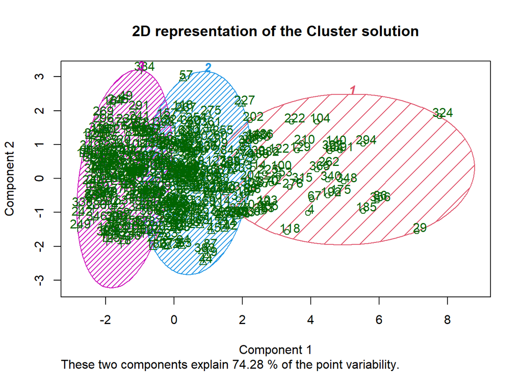

```r
library(cluster)
clusplot(kredi_surekli, km.res$cluster, main='2D representation of the Cluster solution',
         color=TRUE, shade=TRUE,
         labels=2, lines=0)
```

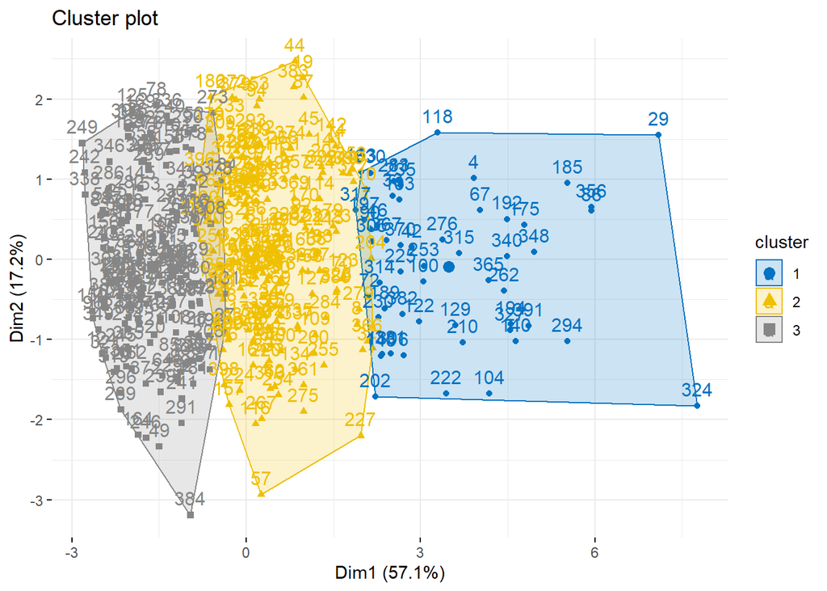

```r
fviz_cluster(km.res, data = kredi_surekli, palette = "jco",
             ggtheme = theme_minimal())
```

## 11.3. Anova

```r
kredi_surekli$cluster=km.res$cluster # Veriye gözlemin atandigi kumenin eklenmesi
kredi_surekli$cluster<-as.factor(kredi_surekli$cluster)
library(rstatix)
#Anova tablosu
Income_aov <- aov(Income ~ cluster, data = kredi_surekli)
summary(Income_aov)
```

```
##              Df Sum Sq Mean Sq F value Pr(>F)
## cluster       2 290561  145281   281.3 <2e-16 ***
## Residuals   397 205060     517
## ---
## Signif. codes:  0 '***' 0.001 '**' 0.01 '*' 0.05 '.' 0.1 ' ' 1
```

$H_0$: Gelir sınıflamada anlamlı bir katkısı vardır.

$H_A$: Gelir sınıflamada anlamlı bir katkısı yoktur.

Değişkenlerin Sig. değerleri 0,05’ten küçük olduğu için $H_0$ rededilmez.

%95 güven ile gelir değişkeni sınıflamada anlamlı katkı sağlamaktadır.

```r
Income_aov <- aov(Limit ~ cluster, data = kredi_surekli)
summary(Income_aov)
```

```
##              Df    Sum Sq   Mean Sq F value Pr(>F)
## cluster       2 1.742e+09 871216799   902.2 <2e-16 ***
## Residuals   397 3.834e+08    965621
## ---
## Signif. codes:  0 '***' 0.001 '**' 0.01 '*' 0.05 '.' 0.1 ' ' 1
```

$H_0$: Limit sınıflamada anlamlı bir katkısı vardır.

$H_A$: Limit sınıflamada anlamlı bir katkısı yoktur.

Değişkenlerin Sig. değerleri 0,05’ten küçük olduğu için $H_0$ rededilmez.

%95 güven ile limit değişkeni sınıflamada anlamlı katkı sağlamaktadır.

```r
Income_aov <- aov(Rating ~ cluster, data = kredi_surekli)
summary(Income_aov)
```

```
##              Df  Sum Sq Mean Sq F value Pr(>F)
## cluster       2 7776812 3888406   869.7 <2e-16 ***
## Residuals   397 1775072    4471
## ---
## Signif. codes:  0 '***' 0.001 '**' 0.01 '*' 0.05 '.' 0.1 ' ' 1
```

$H_0$: Kredi notu sınıflamada anlamlı bir katkısı vardır.

$H_A$: kredi n0tu sınıflamada anlamlı bir katkısı yoktur.

Değişkenlerin Sig. değerleri 0,05’ten küçük olduğu için $H_0$ rededilmez.

%95 güven ile kredi notu değişkeni sınıflamada anlamlı katkı sağlamaktadır.

```r
Income_aov <- aov(Cards ~ cluster, data = kredi_surekli)
summary(Income_aov)
```

```
##              Df Sum Sq Mean Sq F value Pr(>F)
## cluster       2    0.2  0.1071   0.057  0.945
## Residuals   397  750.1  1.8893
```

$H_0$: Kart sayısı sınıflamada anlamlı bir katkısı vardır.

$H_A$: Kart sayısı sınıflamada anlamlı bir katkısı yoktur.

```r
Income_aov <- aov(Age ~ cluster, data = kredi_surekli)
summary(Income_aov)
```

```
##              Df Sum Sq Mean Sq F value  Pr(>F)
## cluster       2   3393  1696.6    5.84 0.00316 **
## Residuals   397 115332   290.5
## ---
## Signif. codes:  0 '***' 0.001 '**' 0.01 '*' 0.05 '.' 0.1 ' ' 1
```

$H_0$: Yaş sınıflamada anlamlı bir katkısı vardır.

$H_A$: Yaş sınıflamada anlamlı bir katkısı yoktur.

Değişkenlerin Sig. değerleri 0,05’ten küçük olduğu için $H_0$ rededilmez.

%95 güven ile yaş değişkeni sınıflamada anlamlı katkı sağlamaktadır.

```r
Income_aov <- aov(Balance ~ cluster, data = kredi_surekli)
summary(Income_aov)
```

```
##              Df   Sum Sq  Mean Sq F value Pr(>F)
## cluster       2 54755460 27377730   367.4 <2e-16 ***
## Residuals   397 29584452    74520
## ---
## Signif. codes:  0 '***' 0.001 '**' 0.01 '*' 0.05 '.' 0.1 ' ' 1
```

$H_0$: Bakiye sınıflamada anlamlı bir katkısı vardır.

$H_A$: Bakiye sınıflamada anlamlı bir katkısı yoktur.

Değişkenlerin Sig. değerleri 0,05’ten küçük olduğu için $H_0$ rededilmez.

%95 güven ile bakiye değişkeni sınıflamada anlamlı katkı sağlamaktadır.